# Generalist herbivore response to volatile chemical induction varies along a gradient in soil salinization | Scientific Reports

### Soil salinity and induction under field conditions

[Full size table](https://www.nature.com/articles/s41598-022-05764-0/tables/2)

**Figure 5**

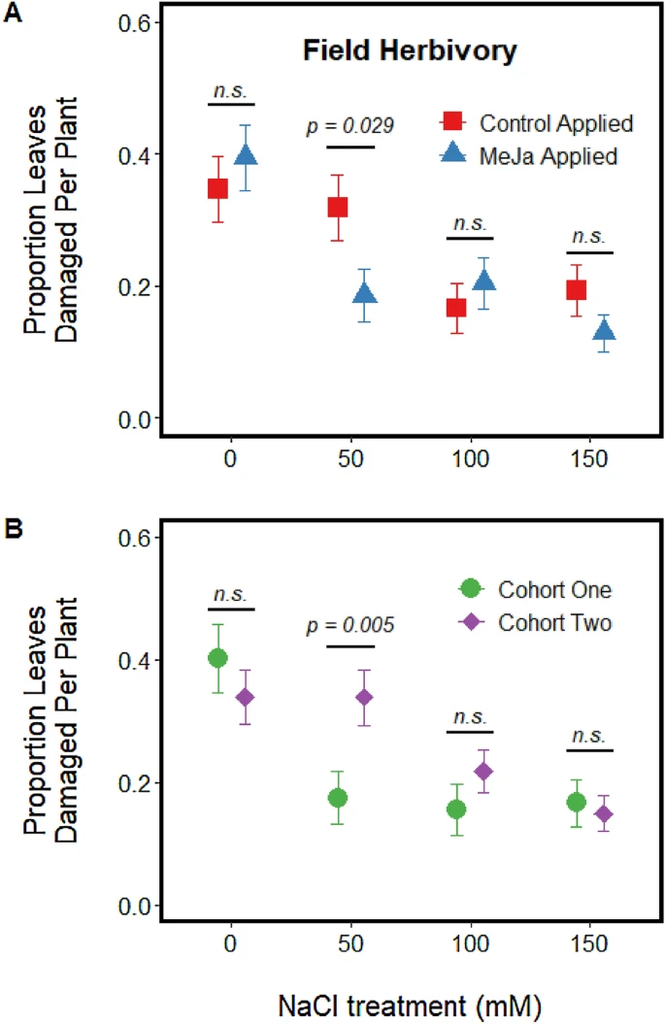

Effects of soil salinization at four concentrations of salt addition (0, 50 100, 150 mM NaCl) on the total proportion of leaves displaying > 10% herbivory in a common garden plot (**A**) after plant induction via exogenous application of methyl jasmonate and (**B**) between cohorts. Bars above each paired data points represent the results of a pairwise contrast testing the effect of chemical induction at each soil salinization level.

[Full size image](https://www.nature.com/articles/s41598-022-05764-0/figures/5)

## Discussion

Our results showed that soil salinization had direct negative effects on plant performance (Fig. S1; *see* Katerji et al. 2003)<sup>46</sup>, limited herbivory<sup>24</sup> (Figs. 1, 5) and modified herbivore development and survival<sup>47</sup> (Figs. 3, 4). Our work demonstrated that plants grown in soils regularly exposed to concentrated salt solutions (e.g., ≥ 50 mM NaCl) experience less leaf consumption by generalist herbivores and the survival of these herbivores is likely limited by the reduction in leaf tissue quality. Our work also demonstrated that induction via methyl jasmonate spray—while reducing leaf consumption at concentrations of NaCl application ≤ 50 mM—has little effect on herbivore damage at greater concentrations of NaCl application.

Thresholds in salt concentrations within the soil generate direct negative effects on plant performance and growth. Tomato growth, for example, is notably susceptible to the effects of soil salinization. Katerji et al. (2003)<sup>46</sup> demonstrated that, similar to other common agricultural crops, increased soil salinization directly limits tomato yield and physiological performance (i.e., evapotranspiration, pre-dawn leaf water potential, stomatal resistance). Our work corroborates this research demonstrating that, with regular applications of solutions > 50 mM sodium chloride, tomato accumulates compounds associated with oxidative stress (i.e., phenolics and other oxidative substrates, Fig. 2A) and exhibits slower physiological processes and growth (Fig. S1). Importantly, growth and stomatal conductance between our 0 mM and 50 mM sodium chloride did not differ, suggesting an important physiological tolerance threshold for tomato is surpassed when solutions > 50 mM sodium chloride are regularly applied. More experimentation using smaller concentration range increments between 0 and 50 mM sodium chloride will be necessary to parameterize tomato physiological response to soil salinization, particularly if these physiological responses to salt addition are non-linear over this concentration range or tomato varieties differ in their tolerance to soil salinity<sup>48</sup>.

Soil salinization and methyl jasmonate applications significantly reduced tomato tissue quality for *S. exigua* with lower larva mass gain and greater larval mortality on salt-treated plants in no-choice feeding trials. Poor leaf tissue quality on host plants generates unique behavioral responses in resident insect herbivores<sup>24,49</sup>. Poor leaf quality may increase larval lepidopteran dispersal<sup>50,51</sup>, resulting in significantly increased predation risk on these herbivores as the larva migrate between host plants<sup>51</sup>. Poor leaf tissue quality can also stimulate intraguild aggression resulting in increased rates of cannibalism<sup>17</sup>. Loss of generalist herbivores to cannibalism can generate growth benefits for host plants<sup>17</sup> and may increase herbivore mortality by increasing viral load transmission between herbivores<sup>52</sup>- *but see* Elderd (2019)<sup>53</sup> -but whether such benefits would persist for salt-stressed plants remains untested. Importantly, recent work indicates that several species of adult female lepidopterans oviposit similarly between plants enriched with sodium chloride and plants untreated with sodium chloride<sup>54</sup>. As sodium-enriched plants are poor food for larval lepidopterans (e.g., Fig. 3) and may delay or preclude pupation (Fig. 4A), soil salinization may directly affect lepidopteran demography. Reduced larval survival due to sodium-enriched, poor-quality host plants may be of concern particularly for endangered lepidopterans (e.g., the monarch butterfly, *Danaus plexippus*)<sup>54</sup> surviving in or migrating through fragmented or urbanized habitats that contain artificially elevated soil salt concentrations. Plants in these salinization-prone habitats, however, may differ in salt tolerance<sup>55</sup> suggesting the impacts of salinization on lepidopteran survival and performance may be a function of lepidopteran specialization and species-specific plant tolerance to soil salinization.

Herbivory in the field and in the lab followed two similar patterns: herbivory declined at more concentrated soil salinization treatments and treatment with MeJa typically deterred herbivory but only at lower soil salinization concentrations. However, application of MeJa influenced leaf consumption only at 0 mM NaCl treatments under laboratory conditions (Fig. 1), but MeJa diminished herbivory for only 50 mM NaCl treated plants under field conditions (Fig. 5). Although it is unclear what generated these differences in MeJa response between soil salinization treatments, it is possible that differences in experimental time scale generated the observed trends. Field plants grew for two weeks after treatment with MeJa and salt imposition treatments were ceased following transplanting. The effects of MeJa treatment are often transient, with peak chemical induction for unstressed plants returning closer to constitutive levels 24–48 h after induction<sup>56</sup>; our laboratory feeding trial captured herbivory patterns during this window of peak induction response. Herbivory on field plants treated with 0 mM NaCl may be comparable between MeJa treatment levels because the extent of defensive chemistry, while initially differing between MeJa treatment levels, was largely comparable between the two MeJa treatment levels for the duration of the time these plants were in the field. Tomatoes in the field treated with 50 mM NaCl, however, had the joint stressors of soil salinization and treatment with MeJa. As soil salinization treatments can generate chemical induction like that observed following leaf wounding<sup>31</sup>, it is possible that the joint treatment of 50 mM NaCl and MeJa spray generated additive levels of defensive chemistry that drove patterns of herbivory that persisted for the two weeks these plants were in the field. Field studies examining temporal trends in secondary chemistry for MeJa-treated plants at different soil salinization levels would help inform if our observed trends are due to temporal differences in plant defensive chemistry.

Estimates of phenolics and other oxidative substrates using Folin-Ciocalteu reagent is a general assay that has been used previously to correlate herbivory, herbivore performance, and plant stress<sup>57</sup>. Importantly, this is a general assay<sup>36</sup> and, while it effectively demonstrates how oxidative stress correlates with plant growth (Fig. 2B), this test does not quantify phenolic compounds closely linked to herbivore performance or leaf consumption (e.g., Chlorogenic acid, flavonoids, tannins)<sup>58</sup>. Unique insect herbivore guilds (i.e., leaf chewers, leaf miners, phloem feeders) respond differently to sodium-treated plants<sup>59</sup> and may respond differently to different groups of phenolics<sup>57</sup>. Our work only examined the effects of soil salinization and induction status on leaf chewers but examining how a wider diversity of insect herbivore functional groups respond to soil salinization and plant induction will help predict how insect herbivores and associated food webs are influenced by greater soil salinity<sup>24</sup>.

Soil salinization requires creative remediation techniques to mitigate deleterious legacies in agroecosystems and roadside habitats. For example, supplementing roadside or agricultural soil with targeted chemical treatments (e.g., calcium or salicylic acid additions) may mitigate the effects of elevated soil salinization on plant survival and performance<sup>61,62</sup>. Arbuscular mycorrhizal fungi can play an important role facilitating plant response to threats from both herbivores<sup>63</sup> and elevated soil salinization<sup>64</sup>, prioritizing strong plant-fungi mutualism as a land management strategy where salt concentrations in the soil are elevated may equip plants with sufficient physiological tools to tolerate adverse conditions. Currently, it is unclear if, or how, remediation translates to variable herbivore survival and growth, but our work demonstrates managing directly for the physiological performance of plants by minimizing the effects of soil salinization will likely have indirect, positive effects for associated herbivores.

## References

1. Assadi, A., Pirnalouti, A. G., Malekpoor, F., Teimori, N. & Assadi, L. Impact of air pollution on physiological and morphological characteristics of *Eucalyptus camaldulensis* Den. *J. Food Agric. Environ.* **9**, 676–679 (2011).

   Google Scholar
2. Rai, R., Rajput, M., Agrawal, M. & Agrawal, S. B. Gaseous air pollutants: A review on current and future trends of emissions and impact on agriculture. *J. Sci. Res.* **55**, 77–102 (2011).

   Google Scholar
3. Brooker, R. W. Plant-plant interactions and environmental change. *New Phytol.* **171**, 271–284. https://doi.org/10.1111/j.1469-8137.2006.01752.x (2006).

   [Article](https://doi.org/10.1111%2Fj.1469-8137.2006.01752.x) [PubMed](http://www.ncbi.nlm.nih.gov/entrez/query.fcgi?cmd=Retrieve&db=PubMed&dopt=Abstract&list_uids=16866935) Google Scholar
4. Jefferies, R. L. & Maron, J. L. The embarrassment of riches: Atmospheric deposition of nitrogen and community and ecosystem processes. *Trends Ecol. Evol.* **12**, 74–78 (1997).

   [CAS](https://www.nature.com/articles/cas-redirect/1:STN:280:DC%2BC3M7itFKjtQ%3D%3D) [Article](https://doi.org/10.1016%2FS0169-5347%2896%2920125-9) Google Scholar
5. Egerton-Warburton, L. M. & Allen, E. B. Shifts in arbuscular mycorrhizal communities along an anthropogenic nitrogen deposition gradient. *Ecol. Appl.* **10**, 484–496 (2000).

   [Article](https://doi.org/10.1890%2F1051-0761%282000%29010%5B0484%3ASIAMCA%5D2.0.CO%3B2) Google Scholar
6. Stiling, P. & Cornelissen, T. How does elevated carbon dioxide (CO<sub>2</sub>) affect plant herbivore interactions? A field experiment and meta-analysis of CO<sub>2</sub>-mediated changes on plant chemistry and herbivore performance. *Glob. Change Biol.* **13**, 1823–1842. https://doi.org/10.1111/j.1365-2486.2007.01392.x (2007).

   [ADS](http://adsabs.harvard.edu/cgi-bin/nph-data_query?link_type=ABSTRACT&bibcode=2007GCBio..13.1823S) [Article](https://doi.org/10.1111%2Fj.1365-2486.2007.01392.x) Google Scholar
7. Zvereva, E. L. & Kozlov, M. V. Consequences of simultaneous elevation of carbon dioxide and temperature for plant-herbivore interactions: A metaanalysis. *Glob. Change Biol.* **12**, 27–41. https://doi.org/10.1111/j.1365-2486.2005.01086.x (2006).

   [ADS](http://adsabs.harvard.edu/cgi-bin/nph-data_query?link_type=ABSTRACT&bibcode=2006GCBio..12...27Z) [Article](https://doi.org/10.1111%2Fj.1365-2486.2005.01086.x) Google Scholar
8. Kopper, B. J. & Lindroth, R. L. Effects of elevated carbon dioxide and ozone on the phytochemistry of aspen and performance of an herbivore. *Oecologia* **134**, 95–103. https://doi.org/10.1007/s00442-002-1090-6 (2003).

   [ADS](http://adsabs.harvard.edu/cgi-bin/nph-data_query?link_type=ABSTRACT&bibcode=2003Oecol.134...95K) [Article](https://doi.org/10.1007%2Fs00442-002-1090-6) [PubMed](http://www.ncbi.nlm.nih.gov/entrez/query.fcgi?cmd=Retrieve&db=PubMed&dopt=Abstract&list_uids=12647186) Google Scholar
9. Maron, J. L. & Crone, E. Herbivory: Effects on plant abundance, distribution and population growth. *Proc. Biol. Sci.* **273**, 2575–2584. https://doi.org/10.1098/rspb.2006.3587 (2006).

   [Article](https://doi.org/10.1098%2Frspb.2006.3587) [PubMed](http://www.ncbi.nlm.nih.gov/entrez/query.fcgi?cmd=Retrieve&db=PubMed&dopt=Abstract&list_uids=17002942) [PubMed Central](http://www.ncbi.nlm.nih.gov/pmc/articles/PMC1635468) Google Scholar
10. Karban, R. & Baldwin, I. T. *Induced Responses to Herbivory* (University of Chicago Press, 2007).

    [Google Scholar](http://scholar.google.com/scholar_lookup?&title=Induced%20Responses%20to%20Herbivory&publication_year=2007&author=Karban%2CR&author=Baldwin%2CIT)
11. Lambers, H. Rising CO<sub>2</sub>, secondary plant metabolism, plant-herbivore interactions and litter decomposition. *Vegetation* **104**(105), 263–271 (1993).

    [Article](https://doi.org/10.1007%2FBF00048157) Google Scholar
12. Poorter, H. *et al.* The effect of elevated CO<sub>2</sub> on the chemical composition and construction costs of leaves of 27 C3 species. *Plant Cell Environ.* **20**, 472–482 (1997).

    [CAS](https://www.nature.com/articles/cas-redirect/1:CAS:528:DyaK2sXjtVOgsrY%3D) [Article](https://doi.org/10.1046%2Fj.1365-3040.1997.d01-84.x) Google Scholar
13. Thaler, J. S., Stout, M. J., Karban, R. & Duffey, S. S. Exogenous jasmonates simulate insect wounding in tomato plants (*Lycopersicon esculentum*) in the laboratory and field. *J. Chem. Ecol.* **22**, 1767–1781 (1996).

    [CAS](https://www.nature.com/articles/cas-redirect/1:CAS:528:DyaK28XnsVajtLg%3D) [Article](https://doi.org/10.1007%2FBF02028503) Google Scholar
14. De Moraes, C. M. *et al.* Herbivore-infested plants selectively attract parasitoids. *Nature* **393**(6685), 570–573 (1998).

    [ADS](http://adsabs.harvard.edu/cgi-bin/nph-data_query?link_type=ABSTRACT&bibcode=1998Natur.393..570D) [Article](https://doi.org/10.1038%2F31219) [Google Scholar](http://scholar.google.com/scholar_lookup?&title=Herbivore-infested%20plants%20selectively%20attract%20parasitoids&journal=Nature&volume=393&issue=6685&pages=570-573&publication_year=1998&author=Moraes%2CCM)
15. Thaler, J. S. Jasmonate-inducible plant defenses cause increased parasitism of herbivores. *Nature* **399**, 686–688 (1999).

    [ADS](http://adsabs.harvard.edu/cgi-bin/nph-data_query?link_type=ABSTRACT&bibcode=1999Natur.399..686T) [CAS](https://www.nature.com/articles/cas-redirect/1:CAS:528:DyaK1MXkt1Sns70%3D) [Article](https://doi.org/10.1038%2F21420) Google Scholar
16. Kessler, A. & Baldwin, I. T. Defensive function of herbivore-induced plant volatile emissions in nature. *Science* **291**(5511), 2141–2144 (2001).

    [ADS](http://adsabs.harvard.edu/cgi-bin/nph-data_query?link_type=ABSTRACT&bibcode=2001Sci...291.2141K) [CAS](https://www.nature.com/articles/cas-redirect/1:CAS:528:DC%2BD3MXitFCltr0%3D) [Article](https://doi.org/10.1126%2Fscience.291.5511.2141) Google Scholar
17. Orrock, J., Connolly, B. & Kitchen, A. Induced defences in plants reduce herbivory by increasing cannibalism. *Nat. Ecol. Evol.* **1**, 1205–1207. https://doi.org/10.1038/s41559-017-0231-6 (2017).

    [Article](https://doi.org/10.1038%2Fs41559-017-0231-6) [PubMed](http://www.ncbi.nlm.nih.gov/entrez/query.fcgi?cmd=Retrieve&db=PubMed&dopt=Abstract&list_uids=29046571) Google Scholar
18. Blande, J. D., Holopainen, J. K. & Niinemets, Ü. Plant volatiles in polluted atmospheres: Stress responses and signal degradation. *Plant Cell Environ.* **37**, 1892–1904. https://doi.org/10.1111/pce.12352 (2014).

    [CAS](https://www.nature.com/articles/cas-redirect/1:CAS:528:DC%2BC2cXhtFOlsLvM) [Article](https://doi.org/10.1111%2Fpce.12352) [PubMed](http://www.ncbi.nlm.nih.gov/entrez/query.fcgi?cmd=Retrieve&db=PubMed&dopt=Abstract&list_uids=24738697) [PubMed Central](http://www.ncbi.nlm.nih.gov/pmc/articles/PMC4289706) Google Scholar
19. Bidart-Bouzat, M. G. & Imeh-Nathaniel, A. Global change effects on plant chemical defenses against insect herbivores. *J. Integr. Plant Biol.* **50**, 1339–1354. https://doi.org/10.1111/j.1744-7909.2008.00751.x (2008).

    [CAS](https://www.nature.com/articles/cas-redirect/1:CAS:528:DC%2BD1cXhsVyltLfE) [Article](https://doi.org/10.1111%2Fj.1744-7909.2008.00751.x) [PubMed](http://www.ncbi.nlm.nih.gov/entrez/query.fcgi?cmd=Retrieve&db=PubMed&dopt=Abstract&list_uids=19017122) Google Scholar
20. Tao, L., Berns, A. R., Hunter, M. D. & Johnson, M. Why does a good thing become too much? Interactions between foliar nutrients and toxins determine performance of an insect herbivore. *Funct. Ecol.* **28**, 190–196. https://doi.org/10.1111/1365-2435.12163 (2014).

    [Article](https://doi.org/10.1111%2F1365-2435.12163) Google Scholar
21. Forieri, I., Hildebrandt, U. & Rostás, M. Salinity stress effects on direct and indirect defence in maize. *Environ. Exp. Bot.* **122**, 68–77. https://doi.org/10.1016/j.envexpbot.2015.09.007 (2016).

    [CAS](https://www.nature.com/articles/cas-redirect/1:CAS:528:DC%2BC2MXhsF2gt7nM) [Article](https://doi.org/10.1016%2Fj.envexpbot.2015.09.007) Google Scholar
22. Maathuis, F. J. Sodium in plants: Perception, signaling, and regulation of sodium fluxes. *J. Exp. Bot.* **65**, 849–858. https://doi.org/10.1093/jxb/ert326 (2014).

    [CAS](https://www.nature.com/articles/cas-redirect/1:CAS:528:DC%2BC2cXisFOjtrs%3D) [Article](https://doi.org/10.1093%2Fjxb%2Fert326) [PubMed](http://www.ncbi.nlm.nih.gov/entrez/query.fcgi?cmd=Retrieve&db=PubMed&dopt=Abstract&list_uids=24151301) Google Scholar
23. Rengasamy, P. World salinization with emphasis on Australia. *J. Exp. Bot.* **57**(5), 1017–1023 (2006).

    [CAS](https://www.nature.com/articles/cas-redirect/1:CAS:528:DC%2BD28Xis1Gls74%3D) [Article](https://doi.org/10.1093%2Fjxb%2Ferj108) [Google Scholar](http://scholar.google.com/scholar_lookup?&title=World%20salinization%20with%20emphasis%20on%20Australia&journal=J.%20Exp.%20Bot.&volume=57&issue=5&pages=1017-1023&publication_year=2006&author=Rengasamy%2CP)
24. Harmon, J. P. & Daigh, A. L. M. Attempting to predict the plant-mediated trophic effects of soil salinity: A mechanistic approach to supplementing insufficient information. *Food Webs* **13**, 67–77. https://doi.org/10.1016/j.fooweb.2017.02.002 (2017).

    [Article](https://doi.org/10.1016%2Fj.fooweb.2017.02.002) Google Scholar
25. Zribi, L. *et al.* Application of chlorophyll fluorescence for the diagnosis of salt stress in tomato “*Solanum lycopersicum* (variety Rio Grande)”. *Sci. Hortic.* **120**, 367–372. https://doi.org/10.1016/j.scienta.2008.11.025 (2009).

    [CAS](https://www.nature.com/articles/cas-redirect/1:CAS:528:DC%2BD1MXivVShsLg%3D) [Article](https://doi.org/10.1016%2Fj.scienta.2008.11.025) Google Scholar
26. Farooq, M. *et al.* Effects, tolerance mechanisms and management of salt stress in grain legumes. *Plant Physiol. Biochem. PPB* **118**, 199–217. https://doi.org/10.1016/j.plaphy.2017.06.020 (2017).

    [CAS](https://www.nature.com/articles/cas-redirect/1:CAS:528:DC%2BC2sXhtVKnsbbJ) [Article](https://doi.org/10.1016%2Fj.plaphy.2017.06.020) [PubMed](http://www.ncbi.nlm.nih.gov/entrez/query.fcgi?cmd=Retrieve&db=PubMed&dopt=Abstract&list_uids=28648997) Google Scholar
27. Zhang, C. *et al.* Uptake and translocation of organic pollutants in plants: A review. *J. Integr. Agric.* **16**, 1659–1668. https://doi.org/10.1016/s2095-3119(16)61590-3 (2017).

    [CAS](https://www.nature.com/articles/cas-redirect/1:CAS:528:DC%2BC2sXhvFOhsL3J) [Article](https://doi.org/10.1016%2Fs2095-3119%2816%2961590-3) Google Scholar
28. Dumbroff, E. B. & Cooper, A. W. Effects of salt stress applied in balanced nutrient solution at several stages during growth of tomato. *Bot. Gazette* **135**, 219–224 (1974).

    [Article](https://doi.org/10.1086%2F336755) Google Scholar
29. Aucejo-Romero, S., Gómez-Cadenas, A. & Jacas-Miret, J.-A. Effects of NaCl-stressed citrus plants on life-history parameters of *Tetranychus urticae* (Acari: Tetranychidae). *Exp. Appl. Acarol.* **33**, 55–67 (2004).

    [Article](https://doi.org/10.1023%2FB%3AAPPA.0000030026.77800.0c) Google Scholar
30. Polack, L. A., Pereyra, P. C. & Sarandón, S. J. Effects of plant stress and habitat manipulation on aphid control in greenhouse sweet peppers. *J. Sustain. Agric.* **35**, 699–725. https://doi.org/10.1080/10440046.2011.606489 (2011).

    [Article](https://doi.org/10.1080%2F10440046.2011.606489) Google Scholar
31. Dombrowski, J. E. Salt stress activation of wound-related genes in tomato plants. *Plant Physiol.* **132**, 2098–2107. https://doi.org/10.1104/pp.102.019927 (2003).

    [CAS](https://www.nature.com/articles/cas-redirect/1:CAS:528:DC%2BD3sXmsVantbw%3D) [Article](https://doi.org/10.1104%2Fpp.102.019927) [PubMed](http://www.ncbi.nlm.nih.gov/entrez/query.fcgi?cmd=Retrieve&db=PubMed&dopt=Abstract&list_uids=12913164) [PubMed Central](http://www.ncbi.nlm.nih.gov/pmc/articles/PMC181293) Google Scholar
32. Younginger, B., Barnouti, J. & Moon, D. Interactive effects of mycorrhizal fungi, salt stress, and competition on the herbivores of *Baccharis halimifolia*. *Ecol. Entomol.* **34**(5), 580–587 (2009).

    [Article](https://doi.org/10.1111%2Fj.1365-2311.2009.01105.x) Google Scholar
33. Orrock, J. L. *et al.* Plants eavesdrop on cues produced by snails and induce costly defenses that affect insect herbivores. *Oecologia* **186**, 703–710. https://doi.org/10.1007/s00442-018-4070-1 (2018).

    [ADS](http://adsabs.harvard.edu/cgi-bin/nph-data_query?link_type=ABSTRACT&bibcode=2018Oecol.186..703O) [Article](https://doi.org/10.1007%2Fs00442-018-4070-1) [PubMed](http://www.ncbi.nlm.nih.gov/entrez/query.fcgi?cmd=Retrieve&db=PubMed&dopt=Abstract&list_uids=29340758) Google Scholar
34. Rodriguez-Saona, C., Chalmers, J. A., Raj, S. & Thaler, J. S. Induced plant responses to multiple damagers: Differential effects on an herbivore and its parasitoid. *Oecologia* **143**, 566–577. https://doi.org/10.1007/s00442-005-0006-7 (2005).

    [ADS](http://adsabs.harvard.edu/cgi-bin/nph-data_query?link_type=ABSTRACT&bibcode=2005Oecol.143..566R) [Article](https://doi.org/10.1007%2Fs00442-005-0006-7) [PubMed](http://www.ncbi.nlm.nih.gov/entrez/query.fcgi?cmd=Retrieve&db=PubMed&dopt=Abstract&list_uids=15791425) Google Scholar
35. Connolly, B. M., Guiden, P. W. & Orrock, J. L. Past freeze–thaw events on *Pinus* seeds increase seedling herbivory. *Ecosphere* **8**, e01748. https://doi.org/10.1002/ecs2.1748 (2017).

    [Article](https://doi.org/10.1002%2Fecs2.1748) Google Scholar
36. Ainsworth, E. A. & Gillespie, K. M. Estimation of total phenolic content and other oxidation substrates in plant tissues using Folin–Ciocalteu reagent. *Nat. Protoc.* **2**, 875–877. https://doi.org/10.1038/nprot.2007.102 (2007).

    [CAS](https://www.nature.com/articles/cas-redirect/1:CAS:528:DC%2BD2sXhtFGnur%2FN) [Article](https://doi.org/10.1038%2Fnprot.2007.102) [PubMed](http://www.ncbi.nlm.nih.gov/entrez/query.fcgi?cmd=Retrieve&db=PubMed&dopt=Abstract&list_uids=17446889) Google Scholar
37. Connolly, B., Ripka, M., & Ebersole, W. Microclimate measurements (15-minute intervals) at Fish Lake Environmental Education Center (Eastern Michigan University; Lapeer County, Michigan, USA), Dryad, Dataset. https://doi.org/10.5061/dryad.3n5tb2rh4 (2021).
38. Edwards, P. J. & Wratten, S. D. Wound induced defenses in plants and their consequences for patterns of insect grazing. *Oecologia* **59**, 88–93 (1983).

    [ADS](http://adsabs.harvard.edu/cgi-bin/nph-data_query?link_type=ABSTRACT&bibcode=1983Oecol..59...88E) [CAS](https://www.nature.com/articles/cas-redirect/1:STN:280:DC%2BC2cbisVyjsA%3D%3D) [Article](https://doi.org/10.1007%2FBF00388079) Google Scholar
39. R Core Team. R Foundation for Statistical Computing. R: A language and environment for statistical computing. Vienna, Austria. [https://www.R-project.org/](https://www.r-project.org/) (2019)
40. Bates, D., Maechler, M., Bolker, B. & Walker, S. Fitting linear mixed-effects models using lme4. *J. Stat. Softw.* **67**(1), 1–48. https://doi.org/10.18637/jss.v067.i01 (2015).

    [Article](https://doi.org/10.18637%2Fjss.v067.i01) Google Scholar
41. Therneau, T. A package for survival analysis in R. R package version 3.2-11. [https://CRAN.R-project.org/package=survival](https://cran.r-project.org/package=survival) (2021)
42. Kassambara, A., Kosinski, M., & Biecek, P. survminer: Drawing survival curves using 'ggplot2'. R package version 0.4.9. [https://CRAN.R-project.org/package=survminer](https://cran.r-project.org/package=survminer) (2021)
43. Wickham, H., François, R., Henry, L., & Müller, K. dplyr: A grammar of data manipulation. R package version 1.0.7. [https://CRAN.R-project.org/package=dplyr](https://cran.r-project.org/package=dplyr) (2021)
44. Lenth, R. V. emmeans: Estimated marginal means, aka least-squares means. R package version 1.6.2-1. [https://CRAN.R-project.org/package=emmeans](https://cran.r-project.org/package=emmeans) (2021)
45. Wickham, H. *ggplot2: Elegant Graphics for Data Analysis* (Springer, 2016).

    [Book](https://doi.org/10.1007%2F978-3-319-24277-4) [Google Scholar](http://scholar.google.com/scholar_lookup?&title=ggplot2%3A%20Elegant%20Graphics%20for%20Data%20Analysis&publication_year=2016&author=Wickham%2CH)
46. Katerji, N., van Hoorn, J. W., Hamdy, A. & Mastrorilli, M. Salinity effect on crop development and yield, analysis of salt tolerance according to several classification methods. *Agric. Water Manag.* **62**, 37–66. https://doi.org/10.1016/s0378-3774(03)00005-2 (2003).

    [Article](https://doi.org/10.1016%2Fs0378-3774%2803%2900005-2) Google Scholar
47. Snell-Rood, E. C., Espeset, A., Boser, C. J., White, W. A. & Smykalski, R. Anthropogenic changes in sodium affect neural and muscle development in butterflies. *Proc. Natl. Acad. Sci. U.S.A.* **111**, 10221–10226. https://doi.org/10.1073/pnas.1323607111 (2014).

    [ADS](http://adsabs.harvard.edu/cgi-bin/nph-data_query?link_type=ABSTRACT&bibcode=2014PNAS..11110221S) [CAS](https://www.nature.com/articles/cas-redirect/1:CAS:528:DC%2BC2cXpsVamu7Y%3D) [Article](https://doi.org/10.1073%2Fpnas.1323607111) [PubMed](http://www.ncbi.nlm.nih.gov/entrez/query.fcgi?cmd=Retrieve&db=PubMed&dopt=Abstract&list_uids=24927579) [PubMed Central](http://www.ncbi.nlm.nih.gov/pmc/articles/PMC4104890) Google Scholar
48. Negrão, S., Schmöckel, S. M. & Tester, M. Evaluating physiological responses of plants to salinity stress. *Ann. Bot.* **119**, 1–11. https://doi.org/10.1093/aob/mcw191 (2017).

    [Article](https://doi.org/10.1093%2Faob%2Fmcw191) [PubMed](http://www.ncbi.nlm.nih.gov/entrez/query.fcgi?cmd=Retrieve&db=PubMed&dopt=Abstract&list_uids=27707746) Google Scholar
49. Mogren, C. L. & Trumble, J. T. The impacts of metals and metalloids on insect behavior. *Entomol. Exp. Appl.* **135**, 1–17. https://doi.org/10.1111/j.1570-7458.2010.00967.x (2010).

    [CAS](https://www.nature.com/articles/cas-redirect/1:CAS:528:DC%2BC3cXltFGjsbk%3D) [Article](https://doi.org/10.1111%2Fj.1570-7458.2010.00967.x) Google Scholar
50. Schultz, J. C. Habitat selection and foraging tactics of caterpillars in heterogeneous trees. In *Variable Plants and Herbivores in Natural and Managed Systems* (eds Denno, R. F. & McClure, M. S.) 61–90 (Academic Press Inc, 1983).

    [Chapter](https://doi.org/10.1016%2FB978-0-12-209160-5.50009-X) [Google Scholar](http://scholar.google.com/scholar_lookup?&title=Habitat%20selection%20and%20foraging%20tactics%20of%20caterpillars%20in%20heterogeneous%20trees&pages=61-90&publication_year=1983&author=Schultz%2CJC)
51. Zalucki, M. P., Clarke, A. R. & Malcolm, S. B. Ecology and behavior of first instar larval lepidoptera. *Annu. Rev. Entomol.* **47**, 361–393 (2002).

    [CAS](https://www.nature.com/articles/cas-redirect/1:CAS:528:DC%2BD38XnvVWmtA%3D%3D) [Article](https://doi.org/10.1146%2Fannurev.ento.47.091201.145220) Google Scholar
52. Elvira, S., Williams, T. & Caballero, P. Juvenile hormone analog technology: Effects on larval cannibalism and the production of *Spodoptera exigua* (Lepidoptera: Noctuidae) nucleopolyhedrovirus. *J. Econ. Entomol.* **103**, 577–582. https://doi.org/10.1603/ec09325 (2010).

    [Article](https://doi.org/10.1603%2Fec09325) [PubMed](http://www.ncbi.nlm.nih.gov/entrez/query.fcgi?cmd=Retrieve&db=PubMed&dopt=Abstract&list_uids=20568601) Google Scholar
53. Elderd, B. D. Bottom-up trait-mediated indirect effects decrease pathogen transmission in a tritrophic system. *Ecology* **100**, e02551 (2019).

    [Article](https://doi.org/10.1002%2Fecy.2551) Google Scholar
54. Mitchell, T. S., Shephard, A. M., Kalinowski, C. R., Kobiela, M. E. & Snell-Rood, E. C. Butterflies do not alter oviposition or larval foraging in response to anthropogenic increases in sodium. *Anim. Behav.* **154**, 121–129. https://doi.org/10.1016/j.anbehav.2019.06.015 (2019).

    [Article](https://doi.org/10.1016%2Fj.anbehav.2019.06.015) Google Scholar
55. Beaton, L. L. & Dudley, S. A. Tolerance to salinity and manganese in three common roadside species. *Int. J. Plant Sci.* **165**, 37–51 (2004).

    [CAS](https://www.nature.com/articles/cas-redirect/1:CAS:528:DC%2BD2cXksVWitLg%3D) [Article](https://doi.org/10.1086%2F380984) Google Scholar
56. Kim, H. *et al.* Effect of methyl jasmonate on phenolics, isothiocyanate, and metabolic enzymes in radish sprout (*Raphanus sativus* L.). *J. Agric. Food Chem.* **54**, 7263–7269 (2006).

    [CAS](https://www.nature.com/articles/cas-redirect/1:CAS:528:DC%2BD28XoslaksL4%3D) [Article](https://doi.org/10.1021%2Fjf060568c) Google Scholar
57. Inbar, M., Doostdar, H. & Mayer, R. T. Suitability of stressed and vigorous plants to various insect herbivores. *Oikos* **94**, 228–235 (2001).

    [Article](https://doi.org/10.1034%2Fj.1600-0706.2001.940203.x) Google Scholar
58. English-Loeb, G., Stout, M. J. & Duffey, S. S. Drought stress in tomatoes: Changes in plant chemistry and potential nonlinear consequences for insect herbivores. *Oikos* **79**, 456–468 (1997).

    [Article](https://doi.org/10.2307%2F3546888) Google Scholar
59. Welti, E. A. R. & Kaspari, M. Sodium addition increases leaf herbivory and fungal damage across four grasslands. *Funct. Ecol.* https://doi.org/10.1111/1365-2435.13796 (2021).

    [Article](https://doi.org/10.1111%2F1365-2435.13796) Google Scholar
60. Caparrotta, S. *et al.* Induction of priming by salt stress in neighboring plants. *Environ. Exp. Bot.* **147**, 261–270. https://doi.org/10.1016/j.envexpbot.2017.12.017 (2018).

    [CAS](https://www.nature.com/articles/cas-redirect/1:CAS:528:DC%2BC1cXjsVaqsQ%3D%3D) [Article](https://doi.org/10.1016%2Fj.envexpbot.2017.12.017) Google Scholar
61. Nedjimi, B. & Daoud, Y. Cadmium accumulation in *Atriplex halimus* subsp. *Schweinfurthii* and its influence on growth, proline, root hydraulic conductivity and nutrient uptake. *Flora Morphol. Distrib. Funct. Ecol. Plants* **204**, 316–324. https://doi.org/10.1016/j.flora.2008.03.004 (2009).

    [Article](https://doi.org/10.1016%2Fj.flora.2008.03.004) Google Scholar
62. Methenni, K. *et al.* Salicylic acid and calcium pretreatments alleviate the toxic effect of salinity in the Oueslati olive variety. *Sci. Hortic.* **233**, 349–358. https://doi.org/10.1016/j.scienta.2018.01.060 (2018).

    [CAS](https://www.nature.com/articles/cas-redirect/1:CAS:528:DC%2BC1cXislOrs7g%3D) [Article](https://doi.org/10.1016%2Fj.scienta.2018.01.060) Google Scholar
63. Song, Y. Y. *et al.* Hijacking common mycorrhizal networks for herbivore-induced defence signal transfer between tomato plants. *Sci. Rep.* **4**, 3915. https://doi.org/10.1038/srep03915 (2014).

    [CAS](https://www.nature.com/articles/cas-redirect/1:CAS:528:DC%2BC2cXlsVCis7w%3D) [Article](https://doi.org/10.1038%2Fsrep03915) [PubMed](http://www.ncbi.nlm.nih.gov/entrez/query.fcgi?cmd=Retrieve&db=PubMed&dopt=Abstract&list_uids=24468912) [PubMed Central](http://www.ncbi.nlm.nih.gov/pmc/articles/PMC3904153) Google Scholar
64. Evelin, H., Kapoor, R. & Giri, B. Arbuscular mycorrhizal fungi in alleviation of salt stress: A review. *Ann. Bot.* **104**, 1263–1280. https://doi.org/10.1093/aob/mcp251 (2009).

    [CAS](https://www.nature.com/articles/cas-redirect/1:CAS:528:DC%2BD1MXhsVKnsLjK) [Article](https://doi.org/10.1093%2Faob%2Fmcp251) [PubMed](http://www.ncbi.nlm.nih.gov/entrez/query.fcgi?cmd=Retrieve&db=PubMed&dopt=Abstract&list_uids=19815570) [PubMed Central](http://www.ncbi.nlm.nih.gov/pmc/articles/PMC2778396) Google Scholar

[Download references](https://citation-needed.springer.com/v2/references/10.1038/s41598-022-05764-0?format=refman&flavour=references)

## Acknowledgements

This manuscript benefitted from feedback provided by the Grman Lab and JL Orrock. Essential support was provided by T. Mast, M. Laporte, the Fish Lake Environmental Education staff, and A. Cross. We thank J. Connolly for logistical support while drafting this manuscript. Funding provided by the EMU Provost office, EMU CAS Dean & Biology Department Awards, and Gonzaga University to BMC, SURF award to JMM, and an EMU eFellows grant to BMC supported equipment for the execution of this work. Funding from USDA-NIFA (award# 2021-67019-33427) supported BMC while writing this manuscript.

## Author information

### Affiliations

1. Department of Biology, Eastern Michigan University, 441 Mark Jefferson Science Complex, Ypsilanti, MI, 48197, USA

   Jocelyn M. Marsack & Brian M. Connolly
2. Biology Department, Gonzaga University, 502 E Boone Ave, Spokane, WA, 99258, USA

   Brian M. Connolly

### Contributions

J.M. and B.C. conceived and designed the experiments. J.M. performed the experiments. B.C. analyzed the data and generated graphics. J.M. led manuscript preparation; B.C. contributed writing and editorial advice.

### Corresponding author

Correspondence to Jocelyn M. Marsack.

## Ethics declarations

### Competing interests

The authors declare no competing interests. JM notes a change of employment during the final preparation of this manuscript and declares no competing interests associated with her employment at CDM Smith. The views of JM are exclusively her own and do not necessarily reflect the views of CDM Smith or its employees and clients.

## Additional information

### Publisher's note

Springer Nature remains neutral with regard to jurisdictional claims in published maps and institutional affiliations.

## Supplementary Information

### [Supplementary Information.](https://static-content.springer.com/esm/art%3A10.1038%2Fs41598-022-05764-0/MediaObjects/41598_2022_5764_MOESM1_ESM.docx)

## Rights and permissions

**Open Access** This article is licensed under a Creative Commons Attribution 4.0 International License, which permits use, sharing, adaptation, distribution and reproduction in any medium or format, as long as you give appropriate credit to the original author(s) and the source, provide a link to the Creative Commons licence, and indicate if changes were made. The images or other third party material in this article are included in the article's Creative Commons licence, unless indicated otherwise in a credit line to the material. If material is not included in the article's Creative Commons licence and your intended use is not permitted by statutory regulation or exceeds the permitted use, you will need to obtain permission directly from the copyright holder. To view a copy of this licence, visit http://creativecommons.org/licenses/by/4.0/.

Reprints and Permissions

## About this article

### Cite this article

Marsack, J.M., Connolly, B.M. Generalist herbivore response to volatile chemical induction varies along a gradient in soil salinization. *Sci Rep* **12,** 1689 (2022). https://doi.org/10.1038/s41598-022-05764-0

[Download citation](https://citation-needed.springer.com/v2/references/10.1038/s41598-022-05764-0?format=refman&flavour=citation)

- Received: 10 June 2021
- Accepted: 13 January 2022
- Published: 01 February 2022
- DOI: https://doi.org/10.1038/s41598-022-05764-0

### Subjects

- [Ecology](https://www.nature.com/subjects/ecology)
- [Environmental sciences](https://www.nature.com/subjects/environmental-sciences)
- [Plant sciences](https://www.nature.com/subjects/plant-sciences)

## Comments

[Download PDF](https://www.nature.com/articles/s41598-022-05764-0.pdf)

[figure not shown]

View PDF